# Chapter 3: Modeling Process Quality

# Learning R and RStudio

Before we start, we need to download R and RStudio.

Go to the link below and download and run the file.  
[Download R](https://cloud.r-project.org/)

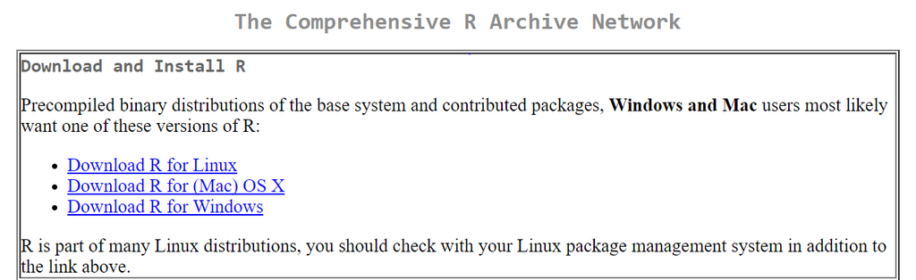

[Download RStudio](https://www.rstudio.com/products/rstudio/download/#download)

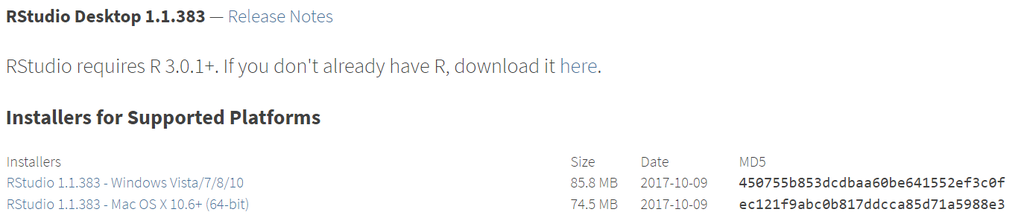

After you download and install the appropriate R and RStudio versions, open RStudio. It should look something like this. (N.B. the author’s personal RStudio console uses a dark theme, but the default background screen is white)

[figure not shown]

Click the button at the top left circled in the above screenshot and press R Script.

[figure not shown]

Your RStudio should look like this

[figure not shown]

Let’s look at each section

### Top Left

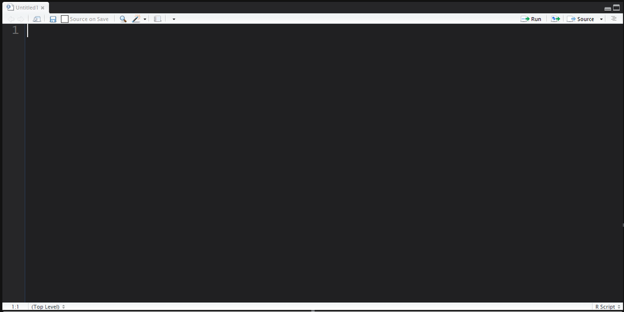

This section is where you will write your R code in a script that you can save and document to look back at. Most of your work will be in this section.

### Top Right

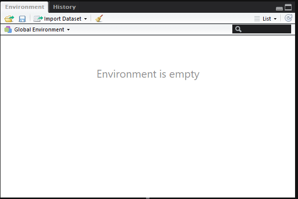

The environment is where your data and objects are stored. If you create a variable, it will be shown here.  
At the end of this tutorial, your environment will be full of variables and objects, like the environment shown below.

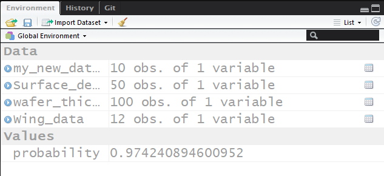

### Bottom right.

[figure not shown]

This section shows you the files on you computer, starting where the R Script file you created is. You can change the location of your file by clicking File and then Save As.

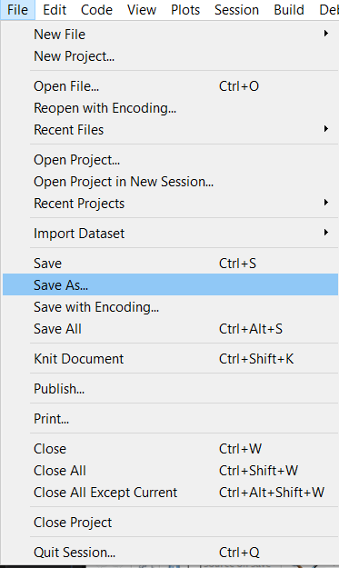

The bottom right section also can show you the graphs you’ll create, packages, help, and Viewer. Here is what a sample graph looks like.

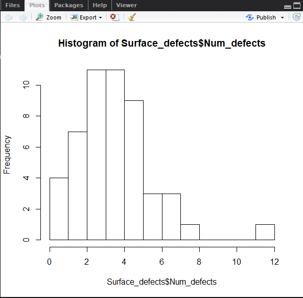

### Bottom left

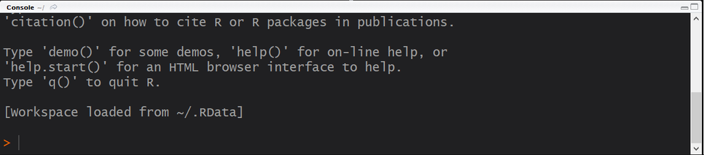

The console runs R code directly. Type x = 5, press enter, and see what happens.

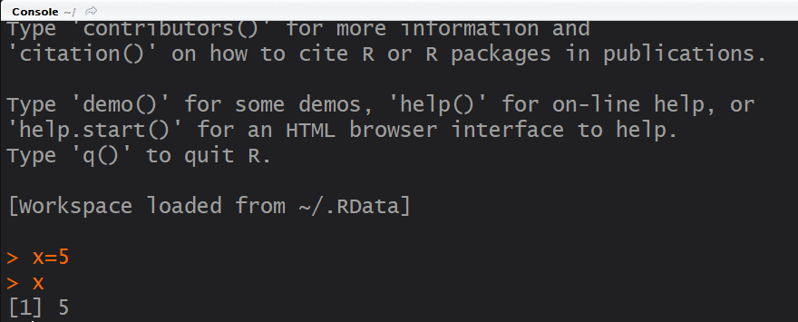

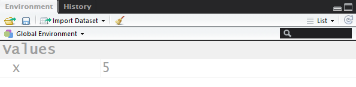

As you can see, the code is run in the console, and the result is shown in the console.

Now write x = 2 in the top left section in the script and press the run button (or press command + enter). This will run the line of code that you are on (line 1 in my case). Check your environment to make sure that it works.

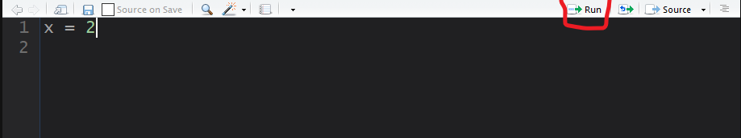

If you need to run every line in the script, press control + alt + R.

That’s essentially how we use RStudio! Before you work on Chapter 3, let’s go over a few concepts we will use.

```r
#this is a comment, if you run this line nothing will happen
#We want to create a dataframe in R. A dataframe is functionally synonymous with an excel spreadsheet, it has columns and rows and data inside
#the c() function stands for concatenate, it is a way for R to group numbers
my_new_dataframe = data.frame(my_numbers = c(1,2,3,4,5,1,3,4,2,4))
print(my_new_dataframe)
```

```
##    my_numbers
## 1           1
## 2           2
## 3           3
## 4           4
## 5           5
## 6           1
## 7           3
## 8           4
## 9           2
## 10          4
```

Now let’s go to Chapter 3 examples.

# Chapter 3 Examples

## Example 3.1: Health Insurance Claims

This example asks us to create a stem and leaf plot from the data given. Here’s the R solution.

```r
#First create a dataframe and input the data
health_data = data.frame(Days = c(48,41,35,36,37,26,36,46,35,47, 35,34,36,42,43,36,56,32,46,30,37,43,17,26,28,27,45,33,22,27,16,22,33,30,24,23,22,30,31,17))

#make the stem and leaf plot using the stem function
#the stem function takes data, and turns it into a stem and leaf plot
#if you want to know more about the stem function, run ?stem in the console
#the $ character specifies the column
#stem is called a function in R, which performs a specific task on your input to give you an output
stem(health_data$Days)
```

```
##
##   The decimal point is 1 digit(s) to the right of the |
##
##   1 | 677
##   2 | 22234
##   2 | 66778
##   3 | 00012334
##   3 | 555666677
##   4 | 1233
##   4 | 56678
##   5 |
##   5 | 6
```

For the first example, a screenshot of the result is included to illustrate how the code should look in your console/script after finishing the example. The rest will not include a screenshot.

[figure not shown]

## Example 3.2:Metal Thickness in Silicon Wafers

This example is actually all about histograms. The histogram function is very easy to use in R, but getting the data can be a pain. Feel free to copy the data entry part if it makes your life easier. Here’s the implementation.

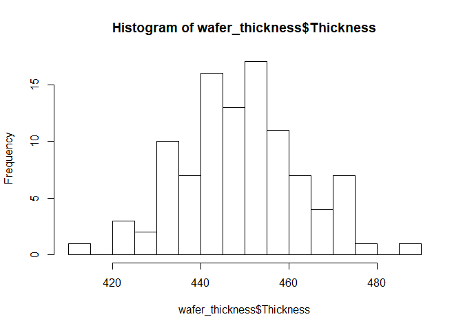

```r
wafer_thickness = data.frame(Thickness = c(438, 450, 487, 451, 452, 441, 444, 461, 432, 471, 413, 450, 430, 437, 465, 444, 471, 453, 431, 458, 444, 450, 446, 444, 466, 458, 471, 452, 455, 445,468, 459, 450, 453, 473, 454, 458, 438, 447, 463, 445, 466, 456, 434, 471, 437, 459, 445, 454, 423, 472, 470, 433, 454, 464, 443, 449, 435, 435, 451, 474, 457, 455, 448, 478, 465, 462, 454, 425, 440, 454, 441, 459, 435, 446, 435, 460, 428, 449, 442, 455, 450, 423, 432, 459, 444, 445, 454, 449, 441, 449, 445, 455, 441, 464, 457, 437, 434, 452, 439))

#the hist function accepts data, as well as the number of desired breaks
#the breaks parameter loosely sets the number of bins in the histogram. It is not an exact bin number due to how the algorithm R uses works
hist(wafer_thickness$Thickness, breaks = 15)
```

## Example 3.3: Defects in Automobile Hoods

This example is remarkably similar to the previous one.

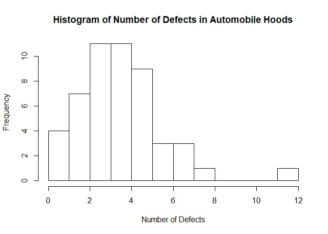

```r
#define the data
Surface_defects = data.frame(Num_defects = c(6,1, 5,7,8,6,0,2,4, 2,5,2, 4,4,1,4,1,7,2, 3,4,3, 3,3,6,3,2,3,4, 5,5,2, 3,4,4,4,2,3,5, 7,5, 4, 5, 5, 4, 5, 3, 3, 3, 12))

#graph using a histogram
#we can label the axes and the title with xlab, ylab, and main
hist(Surface_defects$Num_defects, breaks = 10, xlab = "Number of Defects", ylab = "Frequency", main = "Histogram of Number of Defects in Automobile Hoods")
```

## Example 3.4: Hole Diameter

The focus of this example is using a box plot to visualize hold diameters in wings. Let’s do it in R.

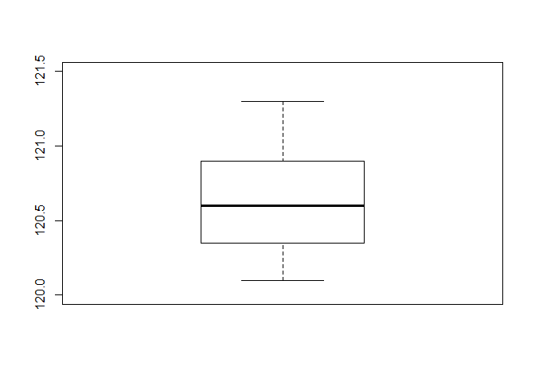

```r
#get the data
Wing_data = data.frame(Hole_diameter = c(120.5, 120.4, 120.7,
120.9, 120.2, 121.1,
120.3, 120.1, 120.9,
121.3, 120.5, 120.8))

#boxplot
#we can set y limits after we have the data using ylim which makes the graph cleaner
boxplot(Wing_data$Hole_diameter, ylim = c(120, 121.5))
```

this boxplot is not very pretty, but is great for visualizing data quickly and getting an idea about the outliers.  
Let’s make up some data (note, this is not part of the book example) to explore the functionality of multiple box plots in R.

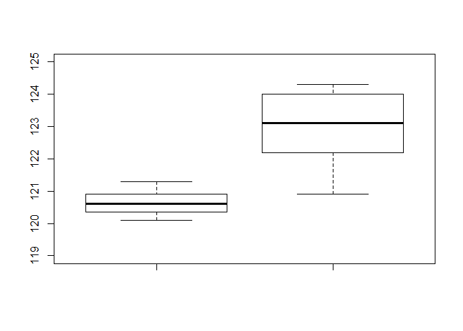

```r
#new data
Wing_data = data.frame(Hole_diameter = c(120.5, 120.4, 120.7, 120.9, 120.2, 121.1, 120.3, 120.1, 120.9, 121.3, 120.5, 120.8), Hole_diameter2 = c(122.5, 121.4, 123.7, 120.9, 124.2, 124.1, 122.3, 122.1, 123.9, 124.3, 122.5, 123.8))
boxplot(Wing_data$Hole_diameter, Wing_data$Hole_diameter2, ylim = c(119, 125 ))
```

## Example 3.5: A Discrete Distribution

For finding the probability of one or fewer noncomforming parts in the sample we use the dbinom function. Here’s how in R.

```r
#add the probability of having 1 error to the probability of having two errors
#the print function outputs the object within its parenthesis
probability = dbinom(0,size = 25, prob = .01) + dbinom(1,size = 25, prob = .01)

print(probability)
```

```
## [1] 0.9742409
```

```r
#we can also print text along with the probability
#we can combine strings of text with numbers using the paste function
#the sep parameter sets what we want to separate each string or number with. In this case, we want a space inbetween "is" and the probability

print(paste("The probability of having one or fewer defects is", probability, sep = " "))
```

```
## [1] "The probability of having one or fewer defects is 0.974240894600952"
```

The probability of having 1 or fewer errors in a sample of 25 is about 97%, which is pretty great! There is an easier way of doing this in R, using a cumulative distribution function for the binomial distribution. We’re also going to round for readability.

```r
probability = round(pbinom(1, size=25, prob=0.01), 2)

print(paste("The probability of having one or fewer defects is ", probability, ".", sep = ""))
```

```
## [1] "The probability of having one or fewer defects is 0.97."
```

That method is much faster, and is generally preferred.

## Example 3.6: A continuous distribution

The example focuses on uniform/continuous distributions, which involves integration instead of summing multiple possibilities. Here’s the corresponding R code.

```r
#The uniform distribution is rather simple to work with, because the probability is simply the fraction of the space occupied by the area desired (in our case, less than or equal to 16)

probability = (16-15.5) / (17-15.5)
print(probability)
```

```
## [1] 0.3333333
```

## Example 3.7: Tensile Strength of Paper

The normal distribution is the focus of this example, with it asking us to find the probability that bags produced from this paper will meet or exceed the specification of greater than or equal to 35 tensile strength given a mean and sd.

```r
#find the one tailed distribution
#pnorm is the standard normal distribution where we define the mean as 40, the stdev as 2, and our value is 35.
#setting the lower.tail parameter as false makes the distribution one tailed, rather than two tailed
print(pnorm((35-40)/2, lower.tail = FALSE))
```

```
## [1] 0.9937903
```

The desired probability is 99.38%

## Example 3.8: Shaft Diameters

This is a two tailed normal distribution problem that is slightly harder than the previous example.  
We want to find the fraction of metal shafts produced that conform to specifications given the mean and standard deviation of the diameter of the metal shaft as well as the desired specifications of the shaft.

```r
#we need to find the probability of x < or = to .2515 and subtract the probability of x < or = to .2485
prob_one = 1 - pnorm((0.2515 - 0.2508)/.0005, lower.tail = F) #F is the same as FALSE
prob_two = 1 - pnorm((0.2485 - 0.2508)/0.0005, lower.tail = F)

Fraction_conforms = round(prob_one - prob_two, 4)

print(paste("The number of shafts that conform to specifications is ", Fraction_conforms, ".", sep = ""))
```

```
## [1] "The number of shafts that conform to specifications is 0.9192."
```

```r
#Now the book asks us what would happen if we changed the process mean to .25, let's see
prob_one = (.2515 - 0.25 ) / 0.0005
prob_two = (.2485 - 0.25) / 0.0005

Fraction_corrected = round((1 - pnorm(prob_one,lower.tail = F)) - (1 - pnorm(prob_two, lower.tail = F)), 4)

paste("The number of shafts that conform to specifications is ", Fraction_corrected, ".", sep = "")
```

```
## [1] "The number of shafts that conform to specifications is 0.9973."
```

If the process mean was a constant .2500, less than 1% of our metal shafts would be outside of specifications.

## Example 3.9: Another Use of the Standard Normal Table

Because we’re in R, we have no use for looking values up in tables, but this problem is about using the normal tables backwards. We use the percent to get a value given a distribution.

```r
#in R, we use the qnorm function for this task
value = qnorm(0.95, mean = 10, sd = 3)
print(value)
```

```
## [1] 14.93456
```

## Example 3.13:Probability Plots

The easiest way to make a probability plot in R is through using what is called a package. A package is how to get use other people’s code, without having to write it yourself. It is a way of getting functions (like the stem(), or hist() functions we’ve been using) that are not automatically included in R.

```r
#first we need to install the necessary package
install.packages("e1071")
```

```r
#now we need to load the package
library(e1071)
```

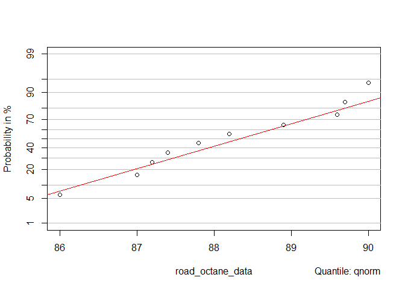

```r
#write in the data
road_octane_data = c(88.9, 87.0, 90.0, 88.2, 87.2, 87.4, 87.8, 89.7, 86.0, 89.6)

#use the probplot() function from the e1071
probplot(road_octane_data)
```

This document was created by Tyler Richards. If you have any questions about it, please reach out at tylerrich@ufl.edu.